# Python Computer Vision

資訊之芽 梁安哲 2024/06/02

# Notes

這個主題是我第一年開，所以有節奏掌握不好的地方歡迎隨時給我回饋。

課程架構參考臺大電機系的選修課：[EEE5053 Computer Vision: from Recognition to Geometry](http://media.ee.ntu.edu.tw/courses/cv/23S/)

# Outline

1. Computer Vision Intro
2. Image Processing
3. Image Filters
4. Image Classification
5. Image Projection
6. Remarks
7. Homework

# Computer Vision Intro

## What is Computer Vision ?

[figure not shown]

讓電腦跟人類一樣看東西的技術。

## A Bit of History

[figure not shown]

"電腦視覺"這個概念緣起於一個 MIT 大一學生的暑假專題。[link](https://people.csail.mit.edu/brooks/idocs/AIM-100.pdf)

## A Bit of History Cont.

[figure not shown]

## A Bit of History Cont.

[figure not shown]

使用各種複雜的數學模型執行任務。

## A Bit of History Cont.

[figure not shown]

# Image Processing

## Before we start

1. `pip install opencv-python`
2. `pip install matplotlib`
3. 準備一個獨立的資料夾裝所有檔案
4. 下載範例資料 link

## Import Packages

```python
import cv2
from matplotlib import pyplot as plt
import numpy as np
```

## Read Image

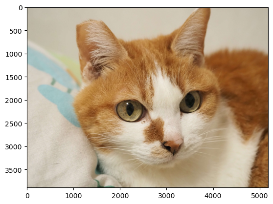

```python
image = cv2.imread("./sample/cat.jpg")
plt.imshow(cv2.cvtColor(image, cv2.COLOR_BGR2RGB))
plt.show()  # 為什麼要使用 cv2.cvtColor ?
```

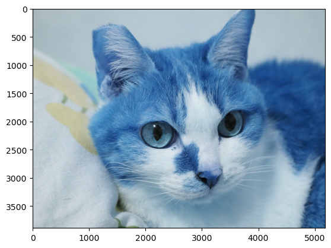

```python
image = cv2.imread("./sample/cat.jpg")
plt.imshow(image)
plt.show()
```

## Image Size

```python
image = cv2.imread("./sample/cat.jpg")
print(image.shape)
```

```
(3888, 5184, 3)
```

## Grayscale

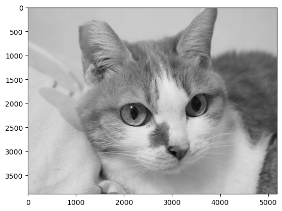

```python
image = cv2.imread("./sample/cat.jpg")
gray_image = cv2.cvtColor(image, cv2.COLOR_BGR2GRAY)
plt.imshow(gray_image, cmap='gray')
plt.show()
```

## Rotate

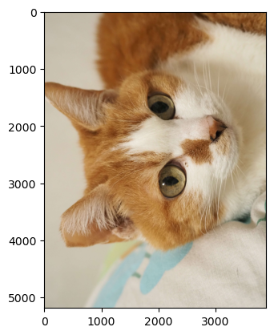

```python
image = cv2.imread("./sample/cat.jpg")
rotated_image = cv2.rotate(image, cv2.ROTATE_90_COUNTERCLOCKWISE)
plt.imshow(cv2.cvtColor(rotated_image, cv2.COLOR_BGR2RGB))
plt.show()
```

## Custom Rotation

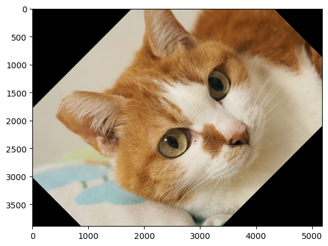

```python
image = cv2.imread("./sample/cat.jpg")
image_center = tuple(np.array(image.shape[1::-1]) / 2)
rotation_matrix = cv2.getRotationMatrix2D(image_center, 45, 1.0)
rotated_image = cv2.warpAffine(
    image, rotation_matrix, image.shape[1::-1], flags=cv2.INTER_LINEAR)
plt.imshow(cv2.cvtColor(rotated_image, cv2.COLOR_BGR2RGB))
plt.show()
```

## Crop

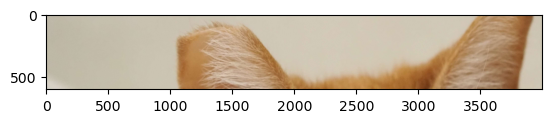

```python
image = cv2.imread("./sample/cat.jpg")
cropped_image = image[200:800, :4000]
plt.imshow(cv2.cvtColor(cropped_image, cv2.COLOR_BGR2RGB))
plt.show()
```

## Practice

1. 把我家貓的鼻子框出來
2. 翻轉180度

[figure not shown]

# Image Filter

[figure not shown]

```python
image = cv2.imread("./sample/leena.png")
plt.imshow(cv2.cvtColor(image, cv2.COLOR_BGR2RGB))
plt.show()
```

## Blur

高斯模糊可以去除圖片中的雜訊，但也會讓圖片變模糊。

[figure not shown]

[figure not shown]

```python
image = cv2.imread("./sample/leena.png")
noise = np.zeros(image.shape, np.uint8)
mean = 0
stddev = 50
cv2.randn(noise, mean, stddev)
noisy_image = cv2.add(image , noise)
plt.imshow(cv2.cvtColor(noisy_image, cv2.COLOR_BGR2RGB))
plt.show()
```

[figure not shown]

```python
blurred_image = cv2.GaussianBlur(noisy_image, (9, 9) , 3)
plt.imshow(cv2.cvtColor(blurred_image, cv2.COLOR_BGR2RGB))
plt.show()
```

## Contrast

### Algorithm

[figure not shown]

[figure not shown]

```python
image = cv2.imread("./sample/leena.png")
enhanced_image = cv2.convertScaleAbs(image, alpha=1.5, beta=0)
plt.imshow(cv2.cvtColor(enhanced_image, cv2.COLOR_BGR2RGB))
plt.show()
```

## Sharpen

[figure not shown]

```python
image = cv2.imread("./sample/leena.png")
kernel = np.array([[0, -1, 0], [-1, 5, -1], [0, -1, 0]])
sharpened_image = cv2.filter2D(image, -1, kernel)
plt.imshow(cv2.cvtColor(sharpened_image, cv2.COLOR_BGR2RGB))
plt.show()
```

## Edge Dection

### Algorithm

[figure not shown]

source:[opencv.org](https://docs.opencv.org/4.x/da/d22/tutorial_py_canny.html)

[figure not shown]

```python
image = cv2.imread("./sample/leena.png")
th1 = 100
th2 = 200
edges = cv2.Canny(image, th1, th2)
plt.imshow(edges , cmap="gray")
plt.show()
```

## Practice

1. 從網路上找一張自己喜歡的圖片
2. 對圖片施加負片後像的效果

# Image Classification

## Machine Learning

有些問題的解法沒辦法很明確的被定義，因此無法人工的方法寫完所有的規則。

例如：如何辨別畫面中的人是男是女、如何把中文翻譯成英文。

機器學習為一種人工智慧的分支，讓程式可以透過我們提供的資料找出問題的解決方法，因此才有"訓練"機器學習模型一說。

[figure not shown]

## 高中生也會的 Deep Learning

所謂問題的解決方法可被視為一個函數 $f(x)$，深度學習代表的是用類似神經元的方式構造一個複雜的函數 $f(x)$，並在訓練的過程中逐步決定各個權重的值為何，讓 $f(x)$ 與訓練資料的差異最小。

[figure not shown]

## 高中生也會的 Deep Learning Cont.

舉最簡單的例子，假設我們的模型為 $f(x)=ax+b$ ，訓練資料有 $g(0)=1$ 和 $g(1)=2$

雖然我們可以很直觀的解出 $a,b$ 兩個參數的最佳解是 $a=1,b=1$ ，但我們可以構造一個函數 $L(a,b)$ 代表 $f(x)$ 和 $g(x)$ 的差異有多大。

則訓練的過程便是想要找到 $L(a,b)$ 的最小值 ，在實務上會對 $L(a,b)$ 這個函數進行偏微分（概念上類似取函數圖形的切線）找出兩個參數 $a,b$ 應該要變動的方向。

[figure not shown]

# Remarks

## Source

1. Multimodal Data Fusion and Analytics Group